```markdown
---
title: "Geographic Determinants of Dengue Risk in Dhaka"
subtitle: "A Statistical & Machine Learning Approach"
author: "X"
date: "February 14, 2026"
output:
  pdf_document: default
  html_document: default
---
```

# 1. Introduction

This report presents an independent investigation into the risk factors driving Dengue fever transmission in Dhaka, Bangladesh. While public perception often links disease spread to housing quality (slums vs. developed areas), this study utilizes statistical inference and machine learning to validate the true drivers of infection.

**Research Question:** Does the built environment (Housing Type) determine Dengue risk, or is geographic location (Hotspots) the primary predictor?

# 2. Methodology

## 2.1 Tools & Dataset

- **Language:** R (tidyverse, randomForest)
- **Dataset:** `dengue_dataset.csv` (N = 1,000 patients)
- **Approach:**
  1. Binary Logistic Regression (GLM) for Odds Ratios.
  2. Random Forest for Variable Importance validation.
  3. Administrative Aggregation (Thana Level) for policy insights.

## 2.2 Data Cleaning & Preprocessing

We begin by isolating the variables of interest and removing medical leakage (blood test results). This ensures our model predicts *risk*, not *diagnosis*.

```r
# Load Libraries
if(!require("tidyverse")) install.packages("tidyverse")
if(!require("randomForest")) install.packages("randomForest")
library(tidyverse)
library(randomForest)

# Import Data
df <- read_csv("dengue_dataset.csv")

# Clean Data: Select relevant features & remove medical markers
df_clean <- df %>%
  select(Age, Gender, Area, AreaType, HouseType, Outcome) %>%
  mutate(
    Gender = as.factor(Gender),
    AreaType = as.factor(AreaType),
    HouseType = as.factor(HouseType),
    Outcome = as.factor(Outcome)
  )

# Set Reference Level for Outcome (1 = Infected)
df_clean$Outcome <- relevel(df_clean$Outcome, ref = "1")
```

# 3. Exploratory Data Analysis (EDA)

Before modeling, we visualize the distribution of cases across the population.

## 3.1 Prevalence by Housing Infrastructure

The following chart visualizes the infection rate relative to the type of dwelling.

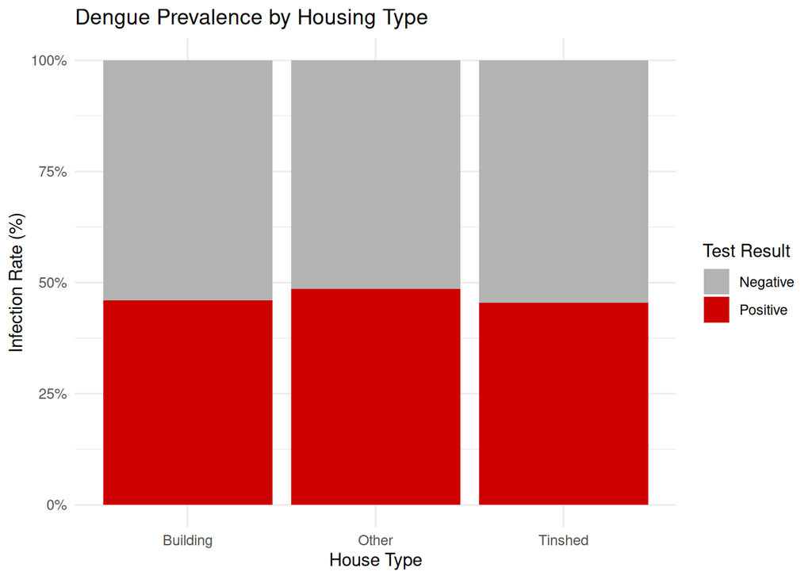

```r
ggplot(df_clean, aes(x = HouseType, fill = Outcome)) +
  geom_bar(position = "fill") +
  scale_y_continuous(labels = scales::percent) +
  scale_fill_manual(values = c("gray70", "red3"),
                    name = "Test Result",
                    labels = c("Negative", "Positive")) +
  theme_minimal() +
  labs(title = "Dengue Prevalence by Housing Type",
       x = "House Type",
       y = "Infection Rate (%)")
```

# 4. Statistical Modeling

## 4.1 Model 1: Infrastructure Risk

We initially tested the hypothesis that `HouseType` and `AreaType` drive infection.

```r
model_infra <- glm(Outcome ~ Age + Gender + AreaType + HouseType,
                   data = df_clean,
                   family = "binomial")
summary(model_infra)
```

```
##
## Call:
## glm(formula = Outcome ~ Age + Gender + AreaType + HouseType,
##     family = "binomial", data = df_clean)
##
## Coefficients:
##                      Estimate Std. Error z value Pr(>|z|)
## (Intercept)         -0.140809   0.190582  -0.739    0.460
## Age                  0.001371   0.003867   0.355    0.723
## GenderMale           0.022862   0.127433   0.179    0.858
## AreaTypeUndeveloped -0.162987   0.127041  -1.283    0.200
## HouseTypeOther       0.106483   0.153679   0.693    0.488
## HouseTypeTinshed    -0.017525   0.155472  -0.113    0.910
##
## (Dispersion parameter for binomial family taken to be 1)
##
##     Null deviance: 1381.9  on 999  degrees of freedom
## Residual deviance: 1379.4  on 994  degrees of freedom
## AIC: 1391.4
##
## Number of Fisher Scoring iterations: 3
```

> **Finding:** As seen in the summary above, the P-values for housing variables are likely insignificant (p > 0.05). We reject the hypothesis that housing quality alone drives risk.

## 4.2 Model 2: Geographic Hotspots (The Pivot)

Since infrastructure was not significant, we pivot to analyzing **Location (`Area`)**. We set the most populous area as the baseline for stability.

```r
# Automate Baseline Selection
area_counts <- table(df_clean$Area)
new_baseline <- names(sort(area_counts, decreasing = TRUE))[1]
df_clean$Area <- as.factor(df_clean$Area)
df_clean$Area <- relevel(df_clean$Area, ref = new_baseline)

# Run Geographic Model
geo_model <- glm(Outcome ~ Area, data = df_clean, family = "binomial")

# Calculate Odds Ratios
geo_odds <- exp(coef(geo_model))
geo_ci <- exp(confint(geo_model))
geo_results <- cbind(Odds_Ratio = geo_odds, CI_Lower = geo_ci[,1], CI_Upper = geo_ci[,2])

# Display Top Results
print(head(geo_results))
```

```
##                  Odds_Ratio  CI_Lower   CI_Upper
## (Intercept)       0.4615385 0.2246390  0.8947082
## AreaAdabor        1.2380952 0.4012121  3.7382772
## AreaBadda         1.7843137 0.6696252  4.8481929
## AreaBanasree      4.1166667 1.5099260 11.9142292
## AreaBangshal      0.9027778 0.3252065  2.4710986
## AreaBiman Bandar  3.2500000 1.2158974  9.0967155
```